# Ejercicio 3. Tarea 2: Consumo. Macroeconomía

## b) Grafíque dichas serie de tiempo juntas para comparalas visualmente. (Compare la gráfica de las variables (de las que son siempre positivas) en dos versiones: a)su valor real original, y b) después de sacarles el logaritmo natural).

#### b.1) Graficando en su valor original:

Para realizar este inciso tuvimos que normalizar las variables para hacerlas comparables, esto debido a que los valores máximos y mínimos de estas son muy disímiles. La normalización se dio a través de la siguiente fórmula:

$Z_i=\frac{X_i- \mu}{\sigma}$

Donde $x_i$ es cada una de las observaciones de las series para cada $t_i$, con $t_i \in[1993I-2021IV]$ lo que nos devolverá un nuevo valor $z_i$ para $t_i\in[1993I-2021IV]$, de esta forma no se pierde ninguna observación y sólo se modifica la escala, lo que nos permite hacer comparaciones entre las variables. En la siguiente gráfica se muestran las variables en niveles: $C$, $Y$, $I$ y $G$.

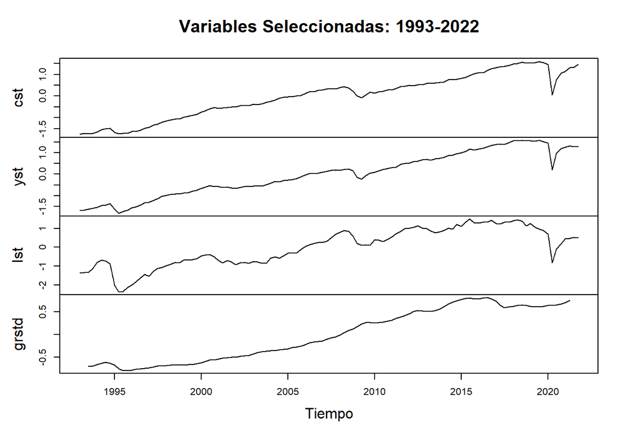

Nótese que estas variables tienen un comportamiento similar. En todo el periodo la tendencia es creciente, con una caída importante durante la pandemia y a partir del Gobierno de Andrés Manuel López Obrador. Nótese, además, que el $G$ tuvo una caída menor, pues a partir de la crisis económica generada por la pandemia el gobierno en turno incentivó la economía a través de una política fiscal expansiva.

#### b.2) Graficando su ln:

Para realizar este inciso se tomaron los $ln(x_i)$ donde $x_i$ es cada variable analizada. En este caso tenemos lo que sigue: $ln(c), ln(Y), ln(I)$ y $ln(G)$ [^4].

Notamos que el comportamiento tendencial de las variables se mantiene: hay una tendencia creciente en el periodo con una variación negativa durante los últimos años del periodo debido a las razones que ya mencionamos.

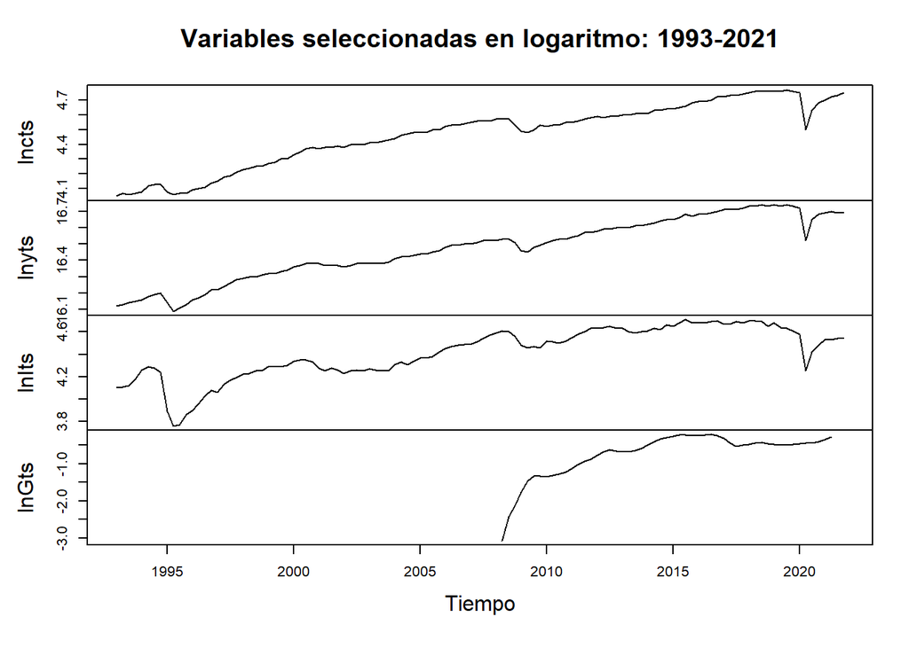

## c) Grafique también la tasa de crecimiento de todas estas series

La tasa de crecimiento de cada una de las series está dada por la siguiente ecuación:

$\delta{x_t}=(X_t - X_{t-1}) / X_{t-1} \times 100$

Donde cada $\delta{x_t}$ es un valor para el tiempo $t$ que medirá la variación que tuvo cada observación respecto al tiempo $t-1$. Este valor está expresado en porcentaje.

En la siguiente gráfica observamos las variaciones de las variables seleccionadas.

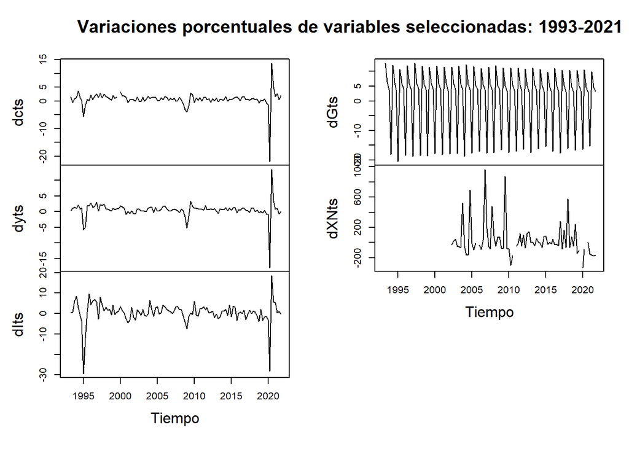